# Assignment 01: Data Visualization Foundations

EPPS 6356 Data Visualization | University of Texas at Dallas

Author

Muhammad Al Hasib

Published

September 21, 2026

## 1. Anscombe’s Quartet

### Visualization

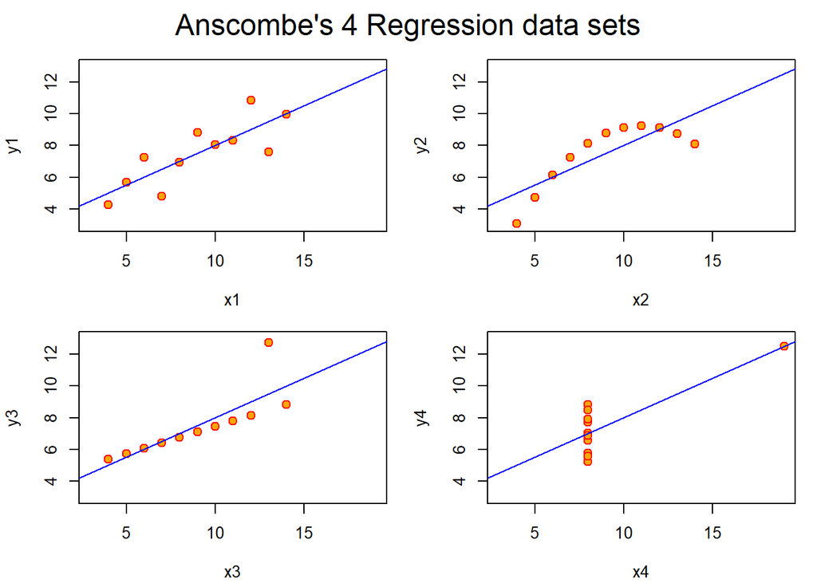

Anscombe’s Four Regression Datasets

```r
data(anscombe)

# Fit linear models for all four datasets
ff <- y ~ x
mods <- setNames(as.list(1:4), paste0("lm", 1:4))

for(i in 1:4) {
  ff[2:3] <- lapply(paste0(c("y","x"), i), as.name)
  mods[[i]] <- lm(ff, data = anscombe)
}

# Plot all four datasets
op <- par(mfrow = c(2, 2), mar = 0.1+c(4,4,1,1), oma = c(0, 0, 2, 0))

for(i in 1:4) {
  ff[2:3] <- lapply(paste0(c("y","x"), i), as.name)
  plot(ff, data = anscombe,
       col = "red", pch = 21, bg = "orange", cex = 1.2,
       xlim = c(3, 19), ylim = c(3, 13))
  abline(mods[[i]], col = "blue")
}

mtext("Anscombe's 4 Regression data sets", outer = TRUE, cex = 1.5)
```

```r
par(op)
```

### Analysis

Anscombe’s Quartet, introduced by Francis J. Anscombe in 1973, presents four datasets that are statistically identical in terms of means, variances, correlations, and regression coefficients, yet reveal fundamentally different patterns when visualized. Dataset I displays a clean linear relationship between x and y. Dataset II follows a nonlinear, curved pattern that a straight regression line poorly represents. Dataset III is nearly perfectly linear except for a single influential outlier that distorts the regression. Dataset IV shows all x values clustered at a single point except one, making the regression line entirely dependent on that one observation. The core lesson is that summary statistics alone are dangerously insufficient for understanding data structure. The solution Anscombe proposed remains essential today: always visualize your data before drawing analytical conclusions, as graphical inspection reveals structural patterns, outliers, and distributional anomalies that numerical summaries systematically conceal.

## 2. Fall.R Visualization

### Custom Fall Color Palette

[figure not shown]

```r
# Note: install packages once if not already installed
# install.packages(c("gsubfn", "proto", "tidyverse"))

library(gsubfn)
library(tidyverse)

# L-system parameters for fall leaf
axiom  <- "X"
rules  <- list("X" = "F-[[X]+X]+F[+FX]-X", "F" = "FF")
angle  <- 22.5
depth  <- 6

for (i in 1:depth) axiom <- gsubfn(".", rules, axiom)

actions <- str_extract_all(axiom, "\\d*\\+|\\d*\\-|F|L|R|\\[|\\]|\\|") %>% unlist

status <- data.frame(x = numeric(0), y = numeric(0), alfa = numeric(0))
points <- data.frame(x1 = 0, y1 = 0, x2 = NA, y2 = NA, alfa = 90, depth = 1)

for (action in actions) {
  if (action == "F") {
    x <- points[1, "x1"] + cos(points[1, "alfa"] * (pi / 180))
    y <- points[1, "y1"] + sin(points[1, "alfa"] * (pi / 180))
    points[1, "x2"] <- x
    points[1, "y2"] <- y
    data.frame(x1 = x, y1 = y, x2 = NA, y2 = NA,
               alfa = points[1, "alfa"],
               depth = points[1, "depth"]) %>% rbind(points) -> points
  }
  if (action %in% c("+", "-")) {
    alfa <- points[1, "alfa"]
    points[1, "alfa"] <- eval(parse(text = paste0("alfa", action, angle)))
  }
  if (action == "[") {
    data.frame(x = points[1, "x1"], y = points[1, "y1"],
               alfa = points[1, "alfa"]) %>% rbind(status) -> status
    points[1, "depth"] <- points[1, "depth"] + 1
  }
  if (action == "]") {
    depth_val <- points[1, "depth"]
    points[-1, ] -> points
    data.frame(x1 = status[1, "x"], y1 = status[1, "y"],
               x2 = NA, y2 = NA,
               alfa = status[1, "alfa"],
               depth = depth_val - 1) %>% rbind(points) -> points
    status[-1, ] -> status
  }
}

ggplot() +
  geom_segment(aes(x = x1, y = y1, xend = x2, yend = y2),
               lineend = "round",
               color = "#8B1A1A",  # Custom: deep crimson fall color
               data = na.omit(points)) +
  coord_fixed(ratio = 1) +
  theme_void() +
  labs(caption = "Fall Leaf | Custom Color: Deep Crimson (#8B1A1A)")
```

## 3. Chart Critique

### Selected Chart

> **Source:** Fox News (2009), as critiqued by Nathan Yau, FlowingData. Retrieved from: https://flowingdata.com/2009/11/26/fox-news-makes-the-best-pie-chart-ever/

[figure not shown]

Fox News Pie Chart: Republican Presidential Candidate Support (2009)

### Critique

The chart above is a pie chart broadcast by Fox News in 2009 showing Republican voter support for three potential 2012 presidential candidates: Sarah Palin (70%), Mike Huckabee (63%), and Mitt Romney (60%). Nathan Yau highlighted this chart on FlowingData as a textbook example of how pie charts can fail both mathematically and visually (Yau, 2024).

**What works:**

The chart uses distinct colors for each candidate, making the three categories immediately distinguishable. Percentage labels are placed directly on the slices, eliminating the need for a separate legend and reducing cognitive effort.

**What does not work:**

The most fundamental problem is mathematical: the three slices sum to 193% rather than 100%, violating the core principle of a pie chart. The slice sizes also do not correspond to the labeled percentages, meaning the visual encoding directly contradicts the data. Beyond the arithmetic error, the chart misrepresents the poll itself — the original question asked about favorability ratings, not presidential support (Bartosik, 2009).

**How to improve it:**

A simple horizontal bar chart would immediately resolve all problems. Bar length accurately encodes magnitude without requiring values to sum to 100%, and comparisons across candidates are easier to read. Adding a clear axis title specifying the question asked — “% of Republicans with favorable opinion” — would further prevent misinterpretation (Yau, 2024).

## References

Anscombe, F. J. (1973). Graphs in statistical analysis. *The American Statistician, 27*(1), 17-21.

Bartosik, M. (2009, November 25). Fox News chart fails math. *NBC Chicago.* https://www.nbcchicago.com/news/local/fox-news-chart-fails-math/2094314/

Yau, N. (2024). *Visualize this: The FlowingData guide to design, visualization, and statistics* (2nd ed.). Wiley.